# Домашнее задание №5

Необходимо выбрать вероятностное распределение на ваш выбор, кроме самых простых (нормальное, равномерное, биномиальное) и в Jupyter Notebook (можно Google Colab) провести следующие эксперименты:

1) Для выбранного распределения сгенерируйте выборки разного объема и проиллюстрируйте сходимость выборочного среднего к математическому ожиданию (покажите наглядно стабилизацию выборочного среднего). 2) Наглядно продемонстрируйте центральную предельную теорему в действии для выбранного вами распределения (покажите сходимость с ростом выборки к нормальному распределению).

Сгенерируйте выборки маленького/среднего/большого размера и для каждой из них постройте:

- асимптотический доверительный интервал для среднего значения на базе ЦПТ
- точный доверительный интервал для среднего значения
- эфронов доверительный интервал для среднего, медианы, моды, дисперсии.

Представьте по пунктам 3-5 сводный датафрейм в читабельном формате и предоставьте вывод о ширинах ДИ, есть ли соответствие фактическому распределению, откуда взята выборка.

**В качестве вероятностного распределения я выбрал гамма-распределение с формой равной 2 и масштабом равным 2**

### Задача 1. Сгенерируем выборки разного объема и проиллюстрируем сходимость выборочного среднего к математическому ожиданию.

```python
# Импортируем необходимые библиотеки
import numpy as np
import pandas as pd
import scipy.stats as sts
from scipy.stats import gamma, norm

import matplotlib.pyplot as plt
import seaborn as sns
plt.style.use('ggplot')
%matplotlib inline

from warnings import simplefilter
simplefilter(action='ignore', category=FutureWarning)
```

Сгенерируем 10 выборок разного объема и изобразим полученные выборки.

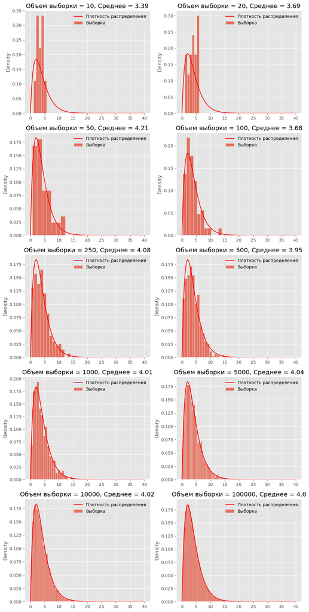

```python
# Задаем параметры гамма распределения
shape = 2
scale = 2

# Создаем фигуру и оси для графиков 5x2
fig, axes = plt.subplots(5, 2, figsize=(10, 20))
axes = axes.flatten()

# Генерируем выборки и строим графики
sample_sizes = [10, 20, 50, 100, 250, 500, 1000, 5000, 10000, 100000]
samples = []
samples_mean = []

for i, sample in enumerate(sample_sizes):
    # Генерируем выборку размером
    data = gamma.rvs(shape, scale=scale, size=sample)
    samples.append(data)
    samples_mean.append(round(np.mean(data), 2))

    # Строим график выборки
    sns.histplot(data, ax=axes[i], stat='density', label='Выборка')
    axes[i].set_title(f'Объем выборки = {sample}, Среднее = {samples_mean[-1]}')

    # Вычисляем значения плотности распределения
    x = np.linspace(0, 40, 100)
    density = gamma.pdf(x, shape, scale=scale)

    # Налагаем плотность на гистограмму
    axes[i].plot(x, density, color='red', label='Плотность распределения')
    axes[i].legend(loc="upper right")

plt.tight_layout()
plt.show()
```

Проиллюстрируем сходимость выборочного среднего к математическому ожиданию. Для этого найдем математической ожидание для данного распределения и параметров, затем построим зависимость среднего числа по выборке от её объёма.

```python
mean = gamma.mean(shape, scale=scale)
```

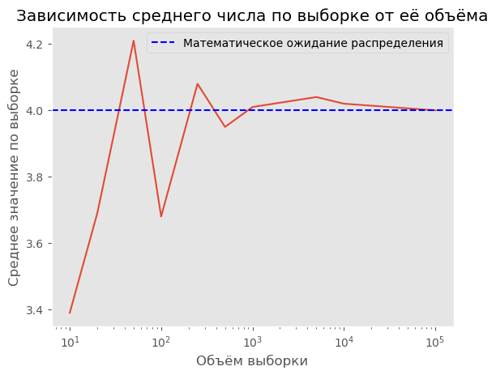

```python
plt.plot(sample_sizes, samples_mean)
plt.axhline(y=mean, color='blue', linestyle='--', label='Математическое ожидание распределения')
plt.xscale('log')
plt.xlabel('Объём выборки')
plt.ylabel('Среднее значение по выборке')
plt.title('Зависимость среднего числа по выборке от её объёма')
plt.grid()
plt.legend(loc="upper right")
plt.show()
```

**Вывод: согласно приведенной зависимости, с увеличением объема выборки среднее значение стремится к математическому ожиданию рассматриваемого распределения, которое равно 4.**

### Задача 2. Наглядно продемонстрируем центральную предельную теорему в действии для выбранного распределения.

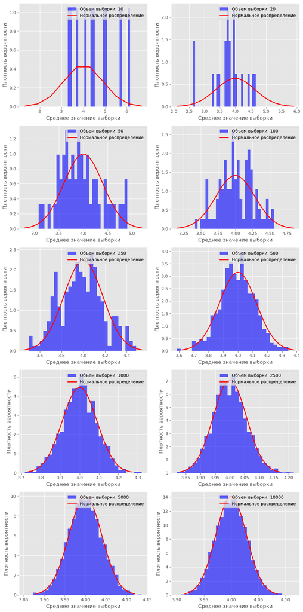

```python
# Генерация выборки из гамма-распределения
shape = 2
scale = 2

# Создаем фигуру и оси для графиков 5x2
fig, axes = plt.subplots(5, 2, figsize=(10, 20))
axes = axes.flatten()

# Генерируем размеры выборки
sample_sizes = [10, 20, 50, 100, 250, 500, 1000, 2500, 5000, 10000]

for i, sample in enumerate(sample_sizes):

    samples = gamma.rvs(shape, scale=scale, size=(sample, sample))

    # Расчет средних значений каждой выборки
    sample_means = np.mean(samples, axis=1)

    # Строим график выборки
    axes[i].hist(sample_means, bins=30, density=True, alpha=0.6, color='b', label=f'Объем выборки: {sample}')

    # Создание нормального распределения для сравнения
    mu = shape * scale  # Математическое ожидание гамма-распределения
    sigma = np.sqrt(shape * scale**2) / np.sqrt(sample)  # Стандартное отклонение сумм
    x = np.linspace(mu - 3*sigma, mu + 3*sigma, sample)
    y = norm.pdf(x, loc=mu, scale=sigma)
    axes[i].plot(x, y, 'r-', linewidth=2, label='Нормальное распределение')

    # Устанавливаем значения осей
    axes[i].set_xlabel('Среднее значение выборки')
    axes[i].set_ylabel('Плотность вероятности')
    axes[i].legend(loc="upper right")

plt.tight_layout()
plt.show()
```

**Вывод: Как можно видеть на графиках представленых выше, при увеличении размера выборки гамма-распределение стремится к нормальному.**

### Задания 3-5. Сгенерируем выборки маленького/среднего/большого размера и для каждой из них построим:

- асимптотический доверительный интервал для среднего значения на базе ЦПТ
- точный доверительный интервал для среднего значения
- эфронов доверительный интервал для среднего, медианы, моды, дисперсии.

```python
# Маленький размер выборки
sample_small = gamma.rvs(2, scale=2, size=100)

# Средний размер выборки
sample_medium = gamma.rvs(2, scale=2, size=1000)

# Большой размер выборки
sample_large = gamma.rvs(2, scale=2, size=10000)
```

```python
# Функция для расчета асимптотического доверительного интервала на базе ЦПТ:
def asymptotic(data, alpha=0.05):
    n = len(data)
    mean = np.mean(data)
    std = np.std(data, ddof=1)
    z = sts.norm.ppf(1 - alpha / 2)
    lower = mean - (z * std / np.sqrt(n))
    upper = mean + (z * std / np.sqrt(n))
    return lower, upper
```

```python
asymptotic_small = asymptotic(sample_small)
asymptotic_medium = asymptotic(sample_medium)
asymptotic_large = asymptotic(sample_large)
```

```python
# Функция для расчета точного доверительного интервала:
def exact(data, alpha=0.05):
    n = len(data)
    mean = np.mean(data)
    std = np.std(data, ddof=1)
    t = sts.t.ppf(1 - alpha / 2, df=n - 1)
    lower = mean - (t * std / np.sqrt(n))
    upper = mean + (t * std / np.sqrt(n))
    return lower, upper
```

```python
exact_small = exact(sample_small)
exact_medium = exact(sample_medium)
exact_large = exact(sample_large)
```

```python
# Функция для расчета эфронова доверительного интервала:
def efron(data, alpha=0.05, n_bootstrap=1000):
    n = len(data)
    mean = np.mean(data)
    median = np.median(data)
    mode = sts.mode(data)[0][0]
    variance = np.var(data)

    bootstrap_samples = np.random.choice(data, size=(n, n_bootstrap), replace=True)

    bootstrap_means = np.mean(bootstrap_samples, axis=0)
    bootstrap_medians = np.median(bootstrap_samples, axis=0)
    bootstrap_modes = sts.mode(bootstrap_samples, axis=0)[0].ravel()
    bootstrap_variances = np.var(bootstrap_samples, axis=0)

    lower_mean = np.percentile(bootstrap_means, q=alpha / 2 * 100)
    upper_mean = np.percentile(bootstrap_means, q=(1 - alpha / 2) * 100)
    lower_median = np.percentile(bootstrap_medians, q=alpha / 2 * 100)
    upper_median = np.percentile(bootstrap_medians, q=(1 - alpha / 2) * 100)
    lower_mode = np.percentile(bootstrap_modes, q=alpha / 2 * 100)
    upper_mode = np.percentile(bootstrap_modes, q=(1 - alpha / 2) * 100)
    lower_variance = np.percentile(bootstrap_variances, q=alpha / 2 * 100)
    upper_variance = np.percentile(bootstrap_variances, q=(1 - alpha / 2) * 100)

    return (lower_mean, upper_mean), (lower_median, upper_median), (lower_mode, upper_mode), (lower_variance, upper_variance)
```

```python
efron_small = efron(sample_small)
efron_medium = efron(sample_medium)
efron_large = efron(sample_large)
```

```python
data = {
    'Маленький размер выборки': [
        asymptotic_small, exact_small, efron_small[0],
        efron_small[1], efron_small[2], efron_small[3]
    ],
    'Средний размер выборки': [
        asymptotic_medium, exact_medium, efron_medium[0],
        efron_medium[1], efron_medium[2], efron_medium[3]
    ],
    'Большой размер выборки': [
        asymptotic_large, exact_large, efron_large[0],
        efron_large[1], efron_large[2], efron_large[3]
    ]
}

df = pd.DataFrame.from_dict(data, orient='index', columns=[
    'Асимптотический доверительный интервал на базе ЦПТ',
    'Точный доверительный интервал',
    'Эфронов доверительный интервал для среднего значения',
    'Эфронов доверительный интервал для медианы',
    'Эфронов доверительный интервал для моды',
    'Эфронов доверительный интервал для дисперсии'
])
df
```

|  | Асимптотический доверительный интервал на базе ЦПТ | Точный доверительный интервал | Эфронов доверительный интервал для среднего значения | Эфронов доверительный интервал для медианы | Эфронов доверительный интервал для моды | Эфронов доверительный интервал для дисперсии |
| --- | --- | --- | --- | --- | --- | --- |
| Маленький размер выборки | (3.20771151500282, 4.280080327494122) | (3.201076667221767, 4.286715175275176) | (3.214305773705321, 4.2882945034762345) | (2.3615506908388446, 3.5561855301437877) | (0.21202933507125743, 8.93565229204437) | (5.287874020907485, 9.647116191548431) |
| Средний размер выборки | (3.80715402075344, 4.168780995738405) | (3.806934690277128, 4.169000326214717) | (3.8026892372328596, 4.152899052403618) | (3.0462265298406597, 3.4944748208310847) | (0.23069490302837212, 9.583528372516248) | (7.502296348799621, 9.586795423075765) |
| Большой размер выборки | (3.9932265232358235, 4.105571530679266) | (3.9932197228251103, 4.105578331089979) | (3.9950745141498785, 4.103690787362526) | (3.353122371932805, 3.478858305544639) | (0.288761317796462, 8.406959297347992) | (7.876416517047791, 8.538651734091138) |